# Week 1 Exercises

**This assignment is due on Friday, 9/5/2025, at 5:00PM**

## Exercise 1

**You can complete this exercise after reading the W01A_FSM_DiagramsTables notebook.**

### *Challenge:* Robot Intersection

Your first assignment is to **develop a state transition diagram and table** for the finite state machine model of the robot intersection shown below.

You have only learned how to design finite state machines, not how to implement and test them. So there is no expectation you can evaluate your design! The assignment is to simply use the tools and knowledge presented in this notebook as best you understand them and submit a design.

However, this does identify a need to learn how to implement your design to see if it will work! Stay tuned!

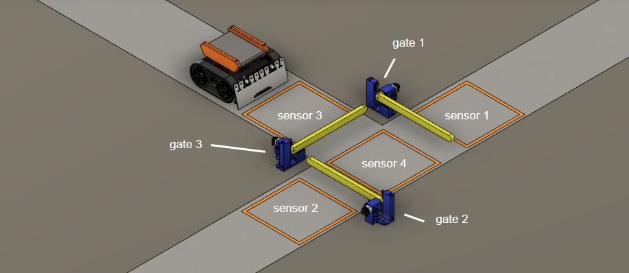

### *Controller Design:* Fixed assumptions

The list below is a set of assumptions that you will incorporate into your system model and controller design. Because they are assumptions they technically could be changed. However, to keep the designs consistent we will consider these **FIXED ASSUMPTIONS** unchangable for this challenge.

**System Model**

- There are inductive vehicle sensors under the path of the robots. Each is "active" or "true" when a robot is positioned over it, and "false" otherwise.

**Controller Design**

- The robots have been programmed by another team to proceed along the first available path that is *not* blocked by a gate. They will stop if all paths are blocked.
- Only 1 robot will be in the intersection at a time.
- All gates will be closed if no robot is present at the intersection.
- When a robot approaching the intersection activates sensor 1, gate 1 and gate 2 will open. The robot will automatically proceed straight ahead and the gates will close when the robot has passed beyond sensor 2.
- When a robot approaching the intersection activates sensor 2, gate 2 and gate 1 will open. The robot will automatically proceed straight ahead and the gates will close when the robot has passed beyond sensor 1.
- When a robot approaching the intersection activates sensor 3, gate 3 and gate 2 will open. The robot will automatically turn right and then proceed ahead. The gates will close when the robot has passed sensor 2.

### *Model Development:* Your Gate System

Although simplistic, explain your "model" for the gate system you're controlling. Describe the relationships between inputs and outputs that you're assuming apply to each of the gate system's components. At this point in the semester, these could be *very* simple, but you need to have expectations for how each of the components will work! **It is likely you'll revist this answer several times in the process as you better understand what kind of model is needed to implement your controller design.**

**This portion of the assignment will be graded for completion.**

### *Controller Design:* Your State Transition Table

Double click on this cell to copy/paste a basic table into the cell below. Add rows and fill it out as needed. **This portion of the assignment will be graded for completion.**

[output not shown]

### *Controller Design:* Your Model Development

Explain the model you used for your controller and what assumptions you made (beyond the fixed assumptions). **This portion of the assignment will be graded for completion.**

### *Controller Validation:* Zumo Intersection

Normally you would validate your model of the controller you designed, but for now you don't have any way to evaluate it. That means that after you've applied the disciplined process as best you understand it, you are done... for now! That means we know what the next step will be... learn HOW to validate our model of our controller design!

The tools you need to design the gate-intersection system are same ones needed to control robots, AI characters in a video game, traffic lights, microwaves, digital watches, etc. Each of these machines and systems share the need to have a control system that makes a "decision" about how it will behave.

### Synchronous FSMs

In this course, we will generally consider *synchronous* state machines, which basically means that their operation is governed by a clock signal executing one command after the other at a specified time. Generally, a synchronous state machine implemented in software consists of an "infinite" program loop that runs over and over. In each "loop" of the program, inputs are measured, logical conditions are evaluated to determine what **state** the machine should be in based on the user inputs and the machine's prior state. Then, at the end of each loop, outputs are written (think motors, lights, buzzers, etc.) based on what state the machine is in.

There are other types of state machines! For more information on types of state machine (this will not be on a test!) you can refer to [this link](https://www.tutorialspoint.com/automata_theory/moore_and_mealy_machines.htm).

Because the state machines we will be implementing in this course are synchronous and running on an infinite loop, they need to make a decision about which state to be in **every time through the loop**. The decision has to be made regardless of whether anything of note has happened, and the software we write to *implement* a FSM must set each boolean state variable to either true or false on each pass through the loop.

## Exercise 2: Boolean Algebra Practice

**You can complete this exercise after reading the W01B_FSM_Boolean notebook.**

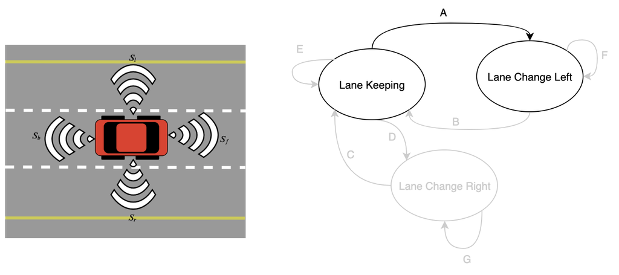

On this vehicle, each of the sensors $S_l,S_r,S_b,S_f$ provides a Boolean "true" to your state machine program when there is something in the way, and "false" otherwise.

Let's consider **only** the transition from "Lake Keeping" to "Lane Change Left" in the diagram above. The desired behavior here is that:

"The vehicle should enter state Lane Change Left (LCL) if it is currently in state Lane Keeping (LK), and if no car is behind us, no car is to our left, and there is a car in front of us."

In attempting to program your finite state machine, you defined the following row in your state transition table:

| Transition | Starting State | Transition Condition | Ending State |
| --- | --- | --- | --- |
| A | Lane Keeping (LK) | $\overline{(S_l\cdot S_b)}\cdot S_f$ | Lane Change Left (LCL) |

The corresponding line of code in your logic program is:

```
A = LK&&!(Sl&&Sb)&&Sf;
```

Unfortunately, your logic for transition "A" is **wrong.** It is not true when you expect and therefore the Lane Change Left state will not be true when needed. Your task is to use the Boolean Algebra simplification rules and a truth table to determine why the logic in the table (which matches the logic in the line of code that sets variable A to either true or false) does **not** produce the desired behavior.

1. **Show a truth table identifying the problem**
2. **Include a short explanation**
3. **Show a *corrected* line of code defining transition A to meet the specifications described above**